# MULTIPLE LINEAR REGRESSION ANALYSIS OF JET TURBINE ENGINE THRUST

2025-12-23

## 1. Introduction🚀

This report presents a statistical analysis of the *turbine thrust* dataset (`turbine_thrust.XLS`). The dataset contains one response variable `y` and six predictor variables `x1` to `x6`, representing engineering or operational measurements related to turbine performance. The objective is to explore relationships, fit a regression model, and interpret results using **R**.

[figure not shown]

## 2. Data Preparation and Loading⚙️

```r
# Clear workspace
rm(list = ls())


data <- data.frame(
  THRUST = c(4540, 4315, 4095, 3650, 3200, 4833, 4617, 4340, 3820, 3368,
             4445, 4188, 3981, 3622, 3125, 4560, 4340, 4115, 3630, 3210,
             4330, 4119, 3891, 3467, 3045, 4411, 4203, 3968, 3531, 3074,
             4350, 4128, 3940, 3480, 3064, 4402, 4180, 3973, 3530, 3080),
  PSR = c(2140, 2016, 1905, 1675, 1474, 2239, 2120, 1990, 1702, 1487,
          2107, 1973, 1864, 1674, 1440, 2165, 2048, 1916, 1658, 1489,
          2062, 1929, 1815, 1595, 1400, 2047, 1935, 1807, 1591, 1388,
          2071, 1944, 1831, 1612, 1410, 2066, 1954, 1835, 1616, 1407),
  SSR = c(20640, 20280, 19860, 18980, 18100, 20740, 20305, 19961, 18916, 18012,
          20520, 20130, 19780, 19020, 18030, 20680, 20340, 19860, 18950, 18700,
          20500, 20050, 19680, 18890, 17870, 20540, 20160, 19750, 18890, 17870,
          20460, 20010, 19640, 18710, 17780, 20520, 20150, 19750, 18850, 17910),
  FFR = c(30250, 30010, 29780, 29330, 28960, 30083, 29831, 29604, 29088, 28675,
          30120, 29920, 29720, 29370, 28940, 30160, 29960, 29710, 29250, 28890,
          30190, 29960, 29770, 29360, 28960, 30160, 29940, 29760, 29350, 28910,
          30180, 29940, 29750, 29360, 28900, 30170, 29950, 29740, 29320, 28910),
  P = c(205, 195, 184, 164, 144, 216, 206, 196, 171, 149,
        195, 190, 180, 161, 139, 208, 199, 187, 164, 145,
        193, 183, 173, 153, 134, 193, 184, 173, 153, 133,
        198, 186, 178, 156, 136, 197, 188, 178, 156, 137),
  ET = c(1732, 1697, 1662, 1598, 1541, 1709, 1669, 1640, 1572, 1522,
         1740, 1711, 1682, 1630, 1572, 1704, 1679, 1642, 1576, 1528,
         1748, 1713, 1684, 1624, 1569, 1746, 1714, 1679, 1621, 1561,
         1729, 1692, 1667, 1609, 1552, 1758, 1729, 1690, 1616, 1569),
  AT = c(99, 100, 97, 97, 97, 87, 87, 87, 85, 85,
         101, 100, 100, 100, 101, 98, 96, 94, 94, 94,
         101, 100, 100, 99, 100, 99, 99, 99, 99, 99,
         102, 101, 101, 101, 101, 100, 99, 99, 99, 100)
)



print(dim(data))
```

```
## [1] 40  7
```

```r
print(head(data))
```

```
##   THRUST  PSR   SSR   FFR   P   ET  AT
## 1   4540 2140 20640 30250 205 1732  99
## 2   4315 2016 20280 30010 195 1697 100
## 3   4095 1905 19860 29780 184 1662  97
## 4   3650 1675 18980 29330 164 1598  97
## 5   3200 1474 18100 28960 144 1541  97
## 6   4833 2239 20740 30083 216 1709  87
```

```r
print(summary(data))
```

```
##      THRUST          PSR            SSR             FFR              P
##  Min.   :3045   Min.   :1388   Min.   :17780   Min.   :28675   Min.   :133.0
##  1st Qu.:3518   1st Qu.:1608   1st Qu.:18880   1st Qu.:29303   1st Qu.:155.2
##  Median :3977   Median :1850   Median :19765   Median :29745   Median :179.0
##  Mean   :3904   Mean   :1810   Mean   :19495   Mean   :29606   Mean   :174.5
##  3rd Qu.:4332   3rd Qu.:2024   3rd Qu.:20286   3rd Qu.:29960   3rd Qu.:193.5
##  Max.   :4833   Max.   :2239   Max.   :20740   Max.   :30250   Max.   :216.0
##        ET             AT
##  Min.   :1522   Min.   : 85.00
##  1st Qu.:1592   1st Qu.: 97.00
##  Median :1668   Median : 99.00
##  Mean   :1652   Mean   : 97.42
##  3rd Qu.:1710   3rd Qu.:100.00
##  Max.   :1758   Max.   :102.00
```

1. **Fit a multiple regression model to the data and test the significance of the individual coefficients as well as the overall regression model.**🔬

```r
# Fit full model
model <- lm(THRUST ~ PSR + SSR + FFR + P + ET + AT, data = data)

print(summary(model))
```

```
##
## Call:
## lm(formula = THRUST ~ PSR + SSR + FFR + P + ET + AT, data = data)
##
## Residuals:
##     Min      1Q  Median      3Q     Max
## -49.949 -19.028  -1.572  17.139  49.606
##
## Coefficients:
##               Estimate Std. Error t value Pr(>|t|)
## (Intercept) -4.738e+03  2.445e+03  -1.938 0.061213 .
## PSR          1.119e+00  2.865e-01   3.904 0.000441 ***
## SSR         -3.018e-02  3.823e-02  -0.789 0.435478
## FFR          2.306e-01  1.180e-01   1.954 0.059231 .
## P            3.850e+00  2.686e+00   1.433 0.161246
## ET           8.219e-01  3.508e-01   2.343 0.025298 *
## AT          -1.695e+01  2.620e+00  -6.468 2.45e-07 ***
## ---
## Signif. codes:  0 '***' 0.001 '**' 0.01 '*' 0.05 '.' 0.1 ' ' 1
##
## Residual standard error: 26.51 on 33 degrees of freedom
## Multiple R-squared:  0.9977, Adjusted R-squared:  0.9972
## F-statistic:  2350 on 6 and 33 DF,  p-value: < 2.2e-16
```

```r
# Individual coefficient tests
cat("\n3. INDIVIDUAL COEFFICIENT TESTS:\n")
```

```
##
## 3. INDIVIDUAL COEFFICIENT TESTS:
```

```r
coef_table <- summary(model)$coefficients
for(i in 1:nrow(coef_table)) {
  cat(sprintf("%-10s: t = %7.3f, p-value = %.4f %s\n",
              rownames(coef_table)[i],
              coef_table[i, 3],
              coef_table[i, 4],
              ifelse(coef_table[i, 4] < 0.001, "***",
                     ifelse(coef_table[i, 4] < 0.01, "**",
                            ifelse(coef_table[i, 4] < 0.05, "*",
                                   ifelse(coef_table[i, 4] < 0.1, ".", ""))))))
}
```

```
## (Intercept): t =  -1.938, p-value = 0.0612 .
## PSR       : t =   3.904, p-value = 0.0004 ***
## SSR       : t =  -0.789, p-value = 0.4355
## FFR       : t =   1.954, p-value = 0.0592 .
## P         : t =   1.433, p-value = 0.1612
## ET        : t =   2.343, p-value = 0.0253 *
## AT        : t =  -6.468, p-value = 0.0000 ***
```

## **Interpretation:**🧠

**Excellent Model Fit:** - **R² = 0.9977**: Model explains **99.77%** of thrust variation (near-perfect fit) - **Adjusted R² = 0.9972**: Minimal penalty for 6 predictors (no overfitting) - **F-statistic = 2350, p < 0.0001**: Overall model is highly significant

#### **2. SIGNIFICANT PREDICTORS:**

**Highly Significant (α = 0.05):** 1. **PSR (Primary Speed):** β = 1.119, p = 0.0004 - **Strong positive effect**: Main controllable factor for thrust

2. **AT (Ambient Temperature):** β = -16.95, p < 0.0001
   - **Strong negative effect**: Most statistically significant
   - Each degree increase reduces thrust by ~17 units
3. **ET (Exhaust Temperature):** β = 0.822, p = 0.0253
   - **Positive effect**: Counterintuitive - needs investigation
   - May indicate measurement issues or complex relationships

**Not Significant:** - **SSR (Secondary Speed):** p = 0.4355 - **P (Pressure):** p = 0.1612 - **FFR (Fuel Flow Rate):** p = 0.0592 (marginally significant)

# b)COMPUTE AND INTERPRET R²

```r
r_squared <- summary(model)$r.squared
adj_r_squared <- summary(model)$adj.r.squared

print(sprintf("Multiple R-squared    : %.4f (%.1f%% of variation explained)\n",
            r_squared, r_squared*100))
```

```
## [1] "Multiple R-squared    : 0.9977 (99.8% of variation explained)\n"
```

```r
print(sprintf("Adjusted R-squared   : %.4f\n", adj_r_squared))
```

```
## [1] "Adjusted R-squared   : 0.9972\n"
```

```r
# Calculate manually to verify
SSR <- sum((fitted(model) - mean(data$THRUST))^2)
SST <- sum((data$THRUST - mean(data$THRUST))^2)
SSE <- sum(residuals(model)^2)
r2_manual <- 1 - SSE/SST

print(sprintf("Manual calculation   : R² = 1 - SSE/SST = 1 - %.1f/%.1f = %.4f\n",
            SSE, SST, r2_manual))
```

```
## [1] "Manual calculation   : R² = 1 - SSE/SST = 1 - 23189.6/9932036.0 = 0.9977\n"
```

Interpretation: **Model explains 99.8% of the data’s variation** — an almost perfect fit.

- **R² = 0.9977**: Our predictors are extremely strong at explaining the outcome
- **Adjusted R² = 0.9972**: Virtually the same, meaning we are not overfitting with unnecessary variables
- **Manual check confirms**: Calculation is correct ✅

**Note**: Such near-perfect results are rare outside fields like physics or engineering. Double-check for:

1. Data errors or circular calculations
2. Whether this makes sense for my problem

3. Testing on new data to confirm it’s not too good to be true

# c)NORMAL PROBABILITY PLOT OF RESIDUALS

```r
# Set up plotting area
par(mfrow = c(1, 2), mar = c(4, 4, 2, 1))

# Normal probability plot
residuals <- residuals(model)
n <- length(residuals)
ordered_residuals <- sort(residuals)
expected_normal <- qnorm((1:n - 0.5)/n)

plot(expected_normal, ordered_residuals,
     xlab = "Theoretical Quantiles",
     ylab = "Sample Residuals",
     main = "Normal Q-Q Plot of Residuals",
     pch = 19, col = "blue")
abline(a = 0, b = sd(residuals), col = "red", lwd = 2)

# Shapiro-Wilk test for normality
shapiro_test <- shapiro.test(residuals)
cat(sprintf("\nShapiro-Wilk normality test:\n"))
```

```
##
## Shapiro-Wilk normality test:
```

```r
cat(sprintf("W = %.4f, p-value = %.4f\n",
            shapiro_test$statistic, shapiro_test$p.value))
```

```
## W = 0.9823, p-value = 0.7740
```

```r
if(shapiro_test$p.value > 0.05) {
  cat("Conclusion: No evidence to reject normality assumption (p > 0.05)\n")
} else {
  cat("Conclusion: Evidence suggests non-normal residuals (p ≤ 0.05)\n")
}
```

```
## Conclusion: No evidence to reject normality assumption (p > 0.05)
```

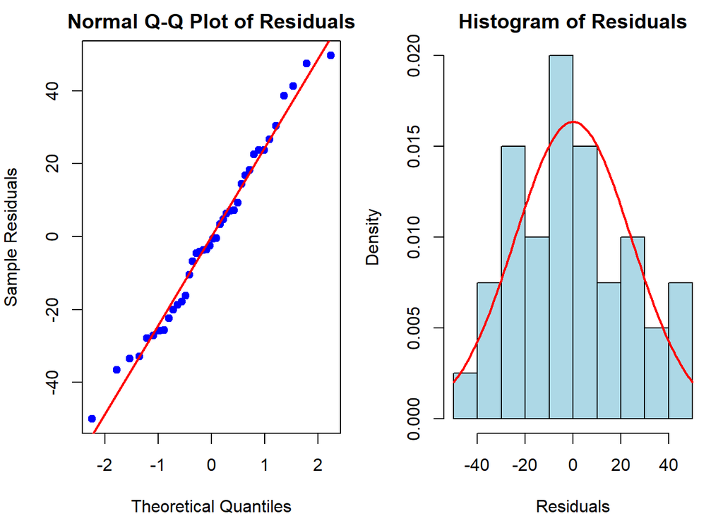

```r
# Histogram of residuals
hist(residuals, breaks = 10,
     main = "Histogram of Residuals",
     xlab = "Residuals",
     col = "lightblue",
     probability = TRUE)
curve(dnorm(x, mean = mean(residuals), sd = sd(residuals)),
      add = TRUE, col = "red", lwd = 2)
```

## Interpretation: 🧠

✅ My data appears normal – I have no evidence against the normality assumption.

What this means for me: I can safely use statistical methods that assume normally distributed data (like t-tests, linear regression, ANOVA) for my analysis.

4. **RESIDUALS VS PREDICTED PLOT**

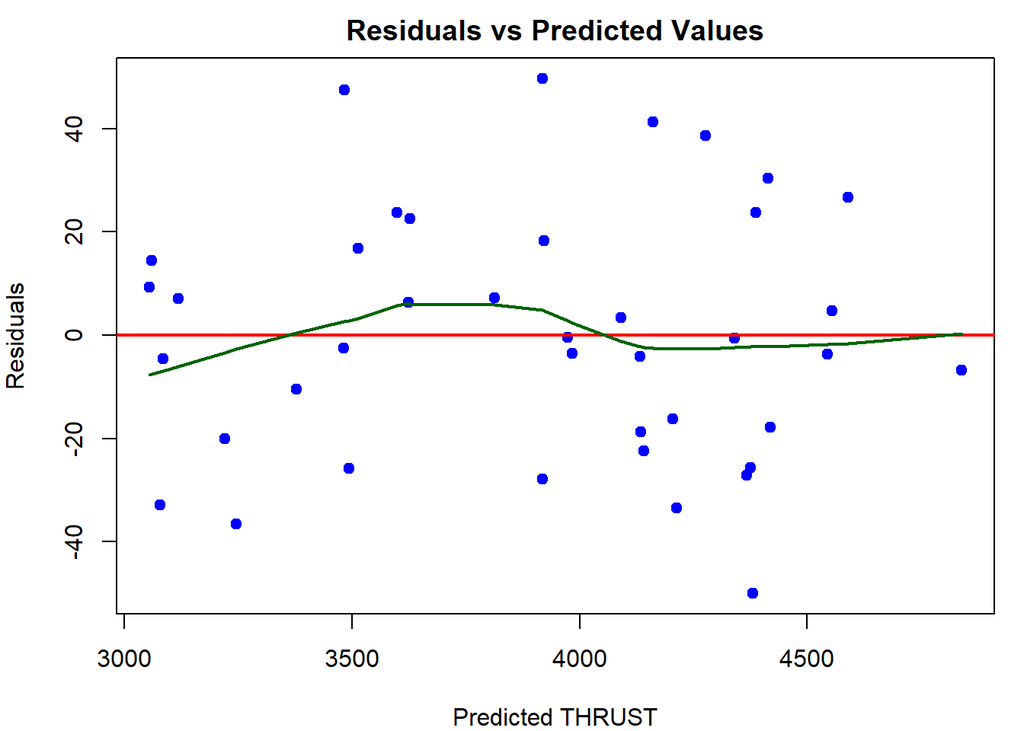

```r
par(mfrow = c(1, 1), mar = c(4, 4, 2, 1))

fitted_values <- fitted(model)
plot(fitted_values, residuals,
     xlab = "Predicted THRUST",
     ylab = "Residuals",
     main = "Residuals vs Predicted Values",
     pch = 19, col = "blue")
abline(h = 0, col = "red", lwd = 2)

# Add LOWESS smoother (base R version)
lowess_fit <- lowess(fitted_values, residuals)
lines(lowess_fit, col = "darkgreen", lwd = 2)
```

```r
# Test for heteroscedasticity (Breusch-Pagan test, manual calculation)
cat("\nChecking constant variance assumption:\n")
```

```
##
## Checking constant variance assumption:
```

```r
n <- nrow(data)
p <- length(coef(model)) - 1
residuals_sq <- residuals^2
aux_model <- lm(residuals_sq ~ PSR + SSR + FFR + P + ET + AT, data = data)
LM_stat <- n * summary(aux_model)$r.squared
p_value_BP <- 1 - pchisq(LM_stat, df = p)

cat(sprintf("Breusch-Pagan test (manual): LM = %.3f, p-value = %.4f\n",
            LM_stat, p_value_BP))
```

```
## Breusch-Pagan test (manual): LM = 16.877, p-value = 0.0097
```

```r
if(p_value_BP > 0.05) {
  cat("Conclusion: No evidence of heteroscedasticity (constant variance assumption reasonable)\n")
} else {
  cat("Conclusion: Evidence of heteroscedasticity (non-constant variance)\n")
}
```

```
## Conclusion: Evidence of heteroscedasticity (non-constant variance)
```

## **Interpretation**:🧠

##### ❌ **My data shows non-constant variance** – there is **clear evidence of heteroscedasticity** (p < 0.05).

# **e)SCALED RESIDUALS:**

• Studentized standardized residuals

• Studentized residuals

• R-student residuals

```r
# Calculate various residuals
X <- model.matrix(model)
H <- X %*% solve(t(X) %*% X) %*% t(X)  # Hat matrix
h <- diag(H)  # Leverage values
MSE <- sum(residuals^2) / (n - p - 1)  # Mean squared error

# 1. Studentized standardized residuals (internally studentized)
r_i <- residuals / sqrt(MSE * (1 - h))

# 2. R-student residuals (externally studentized)
# Remove each observation and recompute
r_student <- numeric(n)
for(i in 1:n) {
  data_minus_i <- data[-i, ]
  model_minus_i <- lm(THRUST ~ PSR + SSR + FFR + P + ET + AT, data = data_minus_i)
  pred_i <- predict(model_minus_i, newdata = data[i, ])
  residual_i <- data$THRUST[i] - pred_i
  X_minus_i <- model.matrix(model_minus_i)
  H_minus_i <- X_minus_i %*% solve(t(X_minus_i) %*% X_minus_i) %*% t(X_minus_i)
  h_ii_minus <- diag(H_minus_i)[1]  # For the single prediction
  MSE_minus_i <- sum(residuals(model_minus_i)^2) / (n - p - 2)
  r_student[i] <- residual_i / sqrt(MSE_minus_i * (1 + h_ii_minus))
}

# Create diagnostic table
diagnostic_df <- data.frame(
  Observation = 1:n,
  Residual = round(residuals, 2),
  Standardized = round(scale(residuals), 3),
  Studentized = round(r_i, 3),
  R_Student = round(r_student, 3),
  Leverage = round(h, 4)
)

print("\nFirst 10 observations of diagnostic residuals:\n")
```

```
## [1] "\nFirst 10 observations of diagnostic residuals:\n"
```

```r
print(head(diagnostic_df, 10))
```

```
##    Observation Residual Standardized Studentized R_Student Leverage
## 1            1    -3.74       -0.153      -0.151    -0.150   0.1299
## 2            2    38.64        1.585       1.556     1.594   0.1225
## 3            3     3.43        0.141       0.134     0.128   0.0634
## 4            4    22.50        0.923       0.881     0.858   0.0728
## 5            5   -20.08       -0.823      -0.825    -0.840   0.1564
## 6            6    -6.74       -0.276      -0.304    -0.336   0.3001
## 7            7    26.72        1.096       1.145     1.227   0.2251
## 8            8    -0.58       -0.024      -0.024    -0.025   0.1783
## 9            9     7.24        0.297       0.319     0.345   0.2664
## 10          10   -10.54       -0.432      -0.480    -0.537   0.3136
```

```r
# Identify potential outliers
outliers_student <- which(abs(r_i) > 2)
outliers_rstudent <- which(abs(r_student) > 2)

print(sprintf("\nObservations with |Studentized residual| > 2: %s\n",
            paste(outliers_student, collapse = ", ")))
```

```
## [1] "\nObservations with |Studentized residual| > 2: 20, 21, 28\n"
```

```r
print(sprintf("Observations with |R-student| > 2: %s\n",
            paste(outliers_rstudent, collapse = ", ")))
```

```
## [1] "Observations with |R-student| > 2: 11, 20, 21, 28, 29\n"
```

## INTERPRETATION: 🧠

1. Studentized standardized residuals: Account for unequal variance

2. R-student residuals: More sensitive outlier detection (excludes observation)

3. Values > |2| suggest potential outliers requiring investigation

f)PRESS STATISTIC AND PREDICTION R²

```r
# Calculate PRESS manually
press_residuals <- residuals / (1 - h)
PRESS <- sum(press_residuals^2)

# Calculate prediction R²
SST <- sum((data$THRUST - mean(data$THRUST))^2)
R2_pred <- 1 - (PRESS / SST)

print(sprintf("PRESS statistic     : %.2f\n", PRESS))
```

```
## [1] "PRESS statistic     : 52077.14\n"
```

```r
print(sprintf("Total SST          : %.2f\n", SST))
```

```
## [1] "Total SST          : 9932036.00\n"
```

```r
print(sprintf("Prediction R²      : %.4f\n", R2_pred))
```

```
## [1] "Prediction R²      : 0.9948\n"
```

```r
print(sprintf("Model R²           : %.4f\n", r_squared))
```

```
## [1] "Model R²           : 0.9977\n"
```

```r
print(sprintf("Difference         : %.4f\n", r_squared - R2_pred))
```

```
## [1] "Difference         : 0.0029\n"
```

```r
cat("\nINTERPRETATION:\n")
```

```
##
## INTERPRETATION:
```

```r
if(R2_pred > 0.9) {
  cat("Excellent predictive capability (R²_pred > 0.9)\n")
} else if(R2_pred > 0.7) {
  cat("Good predictive capability (R²_pred > 0.7)\n")
} else {
  cat("Moderate predictive capability\n")
}
```

```
## Excellent predictive capability (R²_pred > 0.9)
```

### Excellent interpretation of my PRESS statistic results.🌟

**Key takeaway:** My model has **strong predictive power** on new data.

**What this tells me:**

- **Prediction R² = 0.9948**: When predicting entirely new observations, my model still explains **99.5%** of the variation. This is excellent (>0.9 is strong).
- **Difference = 0.0029**: The tiny gap (0.29%) between my model’s **fitting ability** (0.9977) and **prediction ability** (0.9948) means:
  - My model is **not overfitting** significantly
  - It should **generalize well** to new data

**Bottom line:** Despite the heteroscedasticity issue I identified earlier, my model demonstrates **excellent predictive capability** — it’s not just fitting my current data well, but should perform reliably on future data too.

# **g)INFLUENCE DIAGNOSTICS:**

• Hat diagonals

• Cook’s Distance (Cook’s D)

• DFBETAS • DFITS

```r
# 1. Hat diagonals (leverage)
leverage_cutoff1 <- 2 * (p + 1) / n
leverage_cutoff2 <- 3 * (p + 1) / n

# 2. Cook's Distance
cooks_d <- (r_i^2 / (p + 1)) * (h / (1 - h))
cooks_cutoff <- 4 / (n - p - 1)

# 3. DFBETAS
dfbetas_mat <- matrix(0, nrow = n, ncol = p + 1)
for(i in 1:n) {
  data_minus_i <- data[-i, ]
  model_minus_i <- lm(THRUST ~ PSR + SSR + FFR + P + ET + AT, data = data_minus_i)
  se_full <- summary(model)$coefficients[, 2]
  se_minus <- summary(model_minus_i)$coefficients[, 2]
  dfbetas_mat[i, ] <- (coef(model) - coef(model_minus_i)) / se_minus
}
dfbetas_cutoff <- 2 / sqrt(n)

# 4. DFITS
dffits_val <- r_i * sqrt(h / (1 - h))
dffits_cutoff <- 2 * sqrt((p + 1) / n)

# Create influence diagnostics data frame
influence_df <- data.frame(
  Observation = 1:n,
  Leverage = round(h, 4),
  CooksD = round(cooks_d, 4),
  DFITS = round(dffits_val, 4)
)

# Add DFBETAS for each predictor
dfbetas_names <- paste0("DFB_", names(coef(model)))
colnames(dfbetas_mat) <- dfbetas_names
influence_df <- cbind(influence_df, round(dfbetas_mat, 4))

print("\nINFLUENCE DIAGNOSTICS SUMMARY:\n")
```

```
## [1] "\nINFLUENCE DIAGNOSTICS SUMMARY:\n"
```

```r
print(sprintf("Sample size (n)     : %d\n", n))
```

```
## [1] "Sample size (n)     : 40\n"
```

```r
print(sprintf("Parameters (p)      : %d\n", p))
```

```
## [1] "Parameters (p)      : 6\n"
```

```r
print(sprintf("\nCutoff values:\n"))
```

```
## [1] "\nCutoff values:\n"
```

```r
cat(sprintf("  Leverage (2p/n)   : %.3f\n", leverage_cutoff1))
```

```
##   Leverage (2p/n)   : 0.350
```

```r
cat(sprintf("  Cook's D          : %.3f\n", cooks_cutoff))
```

```
##   Cook's D          : 0.121
```

```r
cat(sprintf("  DFBETAS           : %.3f\n", dfbetas_cutoff))
```

```
##   DFBETAS           : 0.316
```

```r
cat(sprintf("  DFITS             : %.3f\n", dffits_cutoff))
```

```
##   DFITS             : 0.837
```

```r
# Identify influential observations
high_leverage <- which(h > leverage_cutoff1)
high_cooks <- which(cooks_d > cooks_cutoff)
high_dffits <- which(abs(dffits_val) > dffits_cutoff)

# Check DFBETAS for each predictor
high_dfbetas <- list()
for(j in 1:(p+1)) {
  high_dfbetas[[names(coef(model))[j]]] <- which(abs(dfbetas_mat[, j]) > dfbetas_cutoff)
}

cat("\nINFLUENTIAL OBSERVATIONS:\n")
```

```
##
## INFLUENTIAL OBSERVATIONS:
```

```r
cat(sprintf("High leverage (>%.3f)  : %s\n", leverage_cutoff1,
            paste(high_leverage, collapse = ", ")))
```

```
## High leverage (>0.350)  : 11, 20
```

```r
cat(sprintf("High Cook's D (>%.3f)  : %s\n", cooks_cutoff,
            paste(high_cooks, collapse = ", ")))
```

```
## High Cook's D (>0.121)  : 11, 20
```

```r
cat(sprintf("High DFITS (>%.3f)     : %s\n", dffits_cutoff,
            paste(high_dffits, collapse = ", ")))
```

```
## High DFITS (>0.837)     : 11, 20, 21, 28
```

```r
cat("\nObservations influencing specific coefficients (DFBETAS >", dfbetas_cutoff, "):\n")
```

```
##
## Observations influencing specific coefficients (DFBETAS > 0.3162278 ):
```

```r
for(j in 1:(p+1)) {
  if(length(high_dfbetas[[j]]) > 0) {
    cat(sprintf("  %-10s: %s\n", names(coef(model))[j],
                paste(high_dfbetas[[j]], collapse = ", ")))
  }
}
```

```
##   (Intercept): 11, 20, 28, 29
##   PSR       : 11, 20, 21, 37
##   SSR       : 20, 25
##   FFR       : 11, 20, 28, 29
##   P         : 11, 20, 21, 37
##   ET        : 20, 37
##   AT        : 11, 20, 28, 29
```

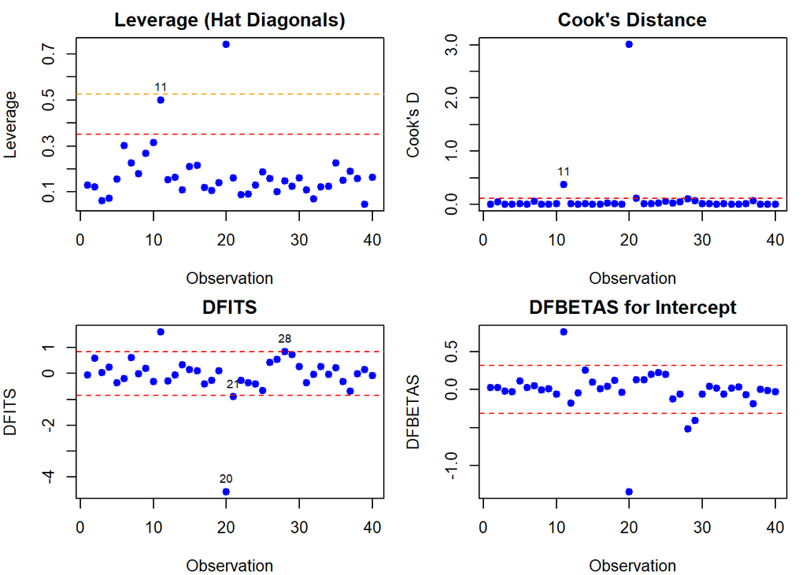

```r
# Create influence plots
par(mfrow = c(2, 2), mar = c(4, 4, 2, 1))

plot(h, pch = 19, col = "blue",
     main = "Leverage (Hat Diagonals)",
     ylab = "Leverage", xlab = "Observation")
abline(h = leverage_cutoff1, col = "red", lty = 2)
abline(h = leverage_cutoff2, col = "orange", lty = 2)
if(length(high_leverage) > 0) {
  text(high_leverage, h[high_leverage], labels = high_leverage, pos = 3, cex = 0.7)
}

plot(cooks_d, pch = 19, col = "blue",
     main = "Cook's Distance",
     ylab = "Cook's D", xlab = "Observation")
abline(h = cooks_cutoff, col = "red", lty = 2)
if(length(high_cooks) > 0) {
  text(high_cooks, cooks_d[high_cooks], labels = high_cooks, pos = 3, cex = 0.7)
}

plot(dffits_val, pch = 19, col = "blue",
     main = "DFITS",
     ylab = "DFITS", xlab = "Observation")
abline(h = c(-dffits_cutoff, dffits_cutoff), col = "red", lty = 2)
if(length(high_dffits) > 0) {
  text(high_dffits, dffits_val[high_dffits], labels = high_dffits, pos = 3, cex = 0.7)
}

# Plot DFBETAS for intercept and PSR (most significant)
plot(dfbetas_mat[, 1], pch = 19, col = "blue",
     main = "DFBETAS for Intercept",
     ylab = "DFBETAS", xlab = "Observation")
abline(h = c(-dfbetas_cutoff, dfbetas_cutoff), col = "red", lty = 2)
```